## What is MICA

MICA is a tool that we’ve developed to try and identify minerals of similar composition - this is a fairly common problem and the identification of a mineral based on it’s chemistry is a difficult task, but hopefully MICA can make it a bit easier!

MICA is built from the database of minerals at webmineral.com which consists of 4722 minerals and 85 elements.

### How are we comparing minerals?

Comparing minerals in 85 dimensional space, would be an impossible task. So using the uwot software package, we’ve reduced the dimensionality of the data to two dimensions, so it’s easier to identify which minerals share a similarity. This can be thought of as an improvement on using either a PCA or a tsne to reduce the dimensionality, both of which would struggle to give a meaningful result with this type of data.

In it’s most basic form, MICA looks like this:

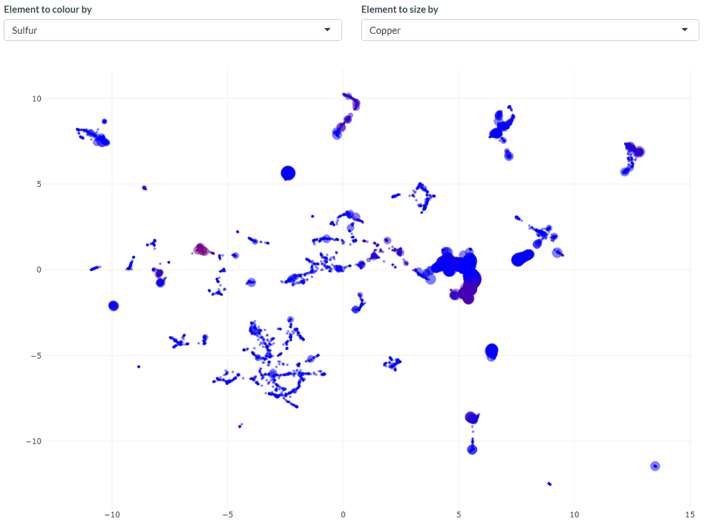

A plot of minerals in 2D. The minerals are coloured by their Sulfur and sized by Copper proportions

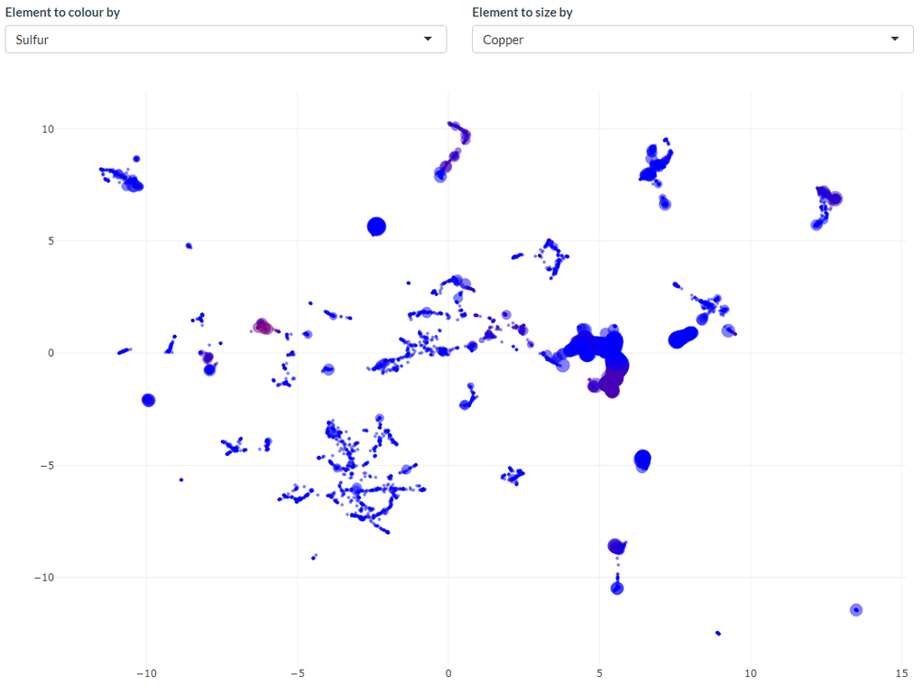

Each of these individual dots represents one of the 4722 minerals found in the webmineral database, the numeric distance between each point isn’t particularly meaningful, but the distance between one point relative to another *is* meaningful. Minerals that have a small distance between them are more similar than those which are far away. We compare them by using a Euclidean distance between the points, in reduced dimensionality space.